# Generative Art

Author

Hannah Pawig

```r
library(tidyverse)
library(scales)
```

```r
# generative dataframe (polar)
# similar to workshop materials, but changed parameters a bit
set.seed(2538)
n <- 100
dat <- tibble(
  x0 = runif(n),
  y0 = runif(n),
  x1 = x0 + runif(n, min = -.5, max = .5),
  y1 = y0 + runif(n, min = -.5, max = .5),
  shade = runif(n),  # for random colors
  size = runif(n)    # for random linewidths
)
```

```r
# This function generates a palette of n random distinct colors
my_pal_generator <- function(seed = NULL, n) {
  if(!is.null(seed)) set.seed(seed)
  sample(colours(distinct = TRUE), size = n, replace = FALSE)
}
gen_pal <- my_pal_generator(seed = 7, n = 4)
show_col(gen_pal) # displays the color palette
```

[figure not shown]

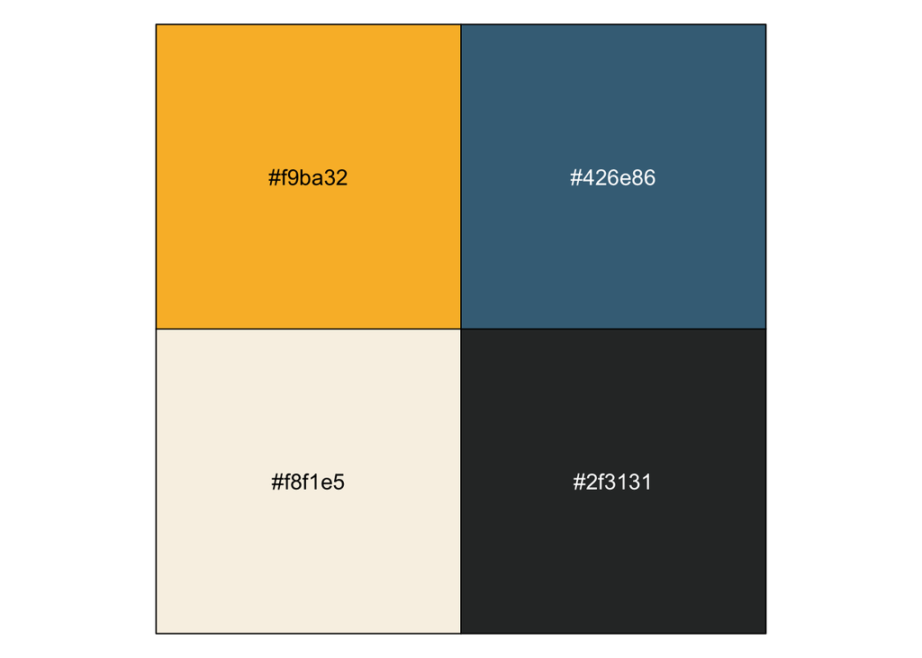

```r
 # Sample from Canva palettes, code is from workshop materials
sample_canva <- function(seed = NULL) {
  if(!is.null(seed)) set.seed(seed)
  sample(ggthemes::canva_palettes, 1)[[1]]
}
pal <- sample_canva(seed = 233)
show_col(pal) # displays the Canva color palette
```

```r
# Function to create a polar-styled plot with ggplot, user just needs plotting data and a palette
# is the "ggplot base" and then you can add geoms after using this function
polar_styled_plot <- function(data = NULL, palette) {
  ggplot(
    data = data,
    mapping = aes(
      x = x0,
      y = y0,
      xend = x1,
      yend = y1,
      colour = shade,
      size = size
    )) +
    coord_polar(clip = "off") +
    scale_y_continuous(
      expand = c(0, 0),
      limits = c(0, 1),
      oob = scales::oob_keep
    ) +
    scale_x_continuous(
      expand = c(0, 0),
      limits = c(0, 1),
      oob = scales::oob_keep
    ) +
    scale_colour_gradientn(colours = palette) +
    scale_size(range = c(0, 10)) +
    theme_void() +
    guides(
      colour = guide_none(),
      size = guide_none(),
      fill = guide_none(),
      shape = guide_none()
    )
}
```

# Piece 1

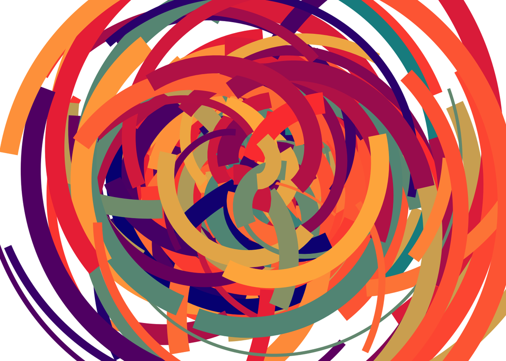

```r
polar_styled_plot(palette = sample_canva(seed = 2461)) +
  geom_segment(data = dat) +
  geom_segment(data = dat |> mutate(y1 = y1 - .4, y0 = y0 - 0.4)) +
  geom_segment(data = dat |> mutate(y1 = y1 - .3, y0 = y0 - .3)) +
  geom_segment(data = dat |> mutate(y1 = y1 * 1.75, y0 = y0 * 1.75))
```

**Exhibit: “Tropical Blooming Vortex”**

# Piece 2

First, we’ll load in some customized plotting functions

```r
polar_art <- function(seed, n, palette) {

  # set the state of the random number generator
  set.seed(seed)

  # data frame containing random values for
  # aesthetics we might want to use in the art
  dat <- tibble(
    x0 = runif(n),
    y0 = runif(n),
    x1 = x0 - runif(n, min = -.3, max = .3),
    y1 = y0 +- runif(n, min = -.4, max = .4),
    shade = runif(n),
    size = runif(n)
  )

  # plot segments in various colours, using
  # polar coordinates and a gradient palette
  dat |>
    ggplot(aes(
      x = x0,
      y = y0,
      xend = x1,
      yend = y1,
      colour = shade,
      size = size
    )) +
    geom_segment(show.legend = FALSE) +
    coord_polar() +
    scale_y_continuous(expand = c(0, 0)) +
    scale_x_continuous(expand = c(0, 0)) +
    scale_colour_gradientn(colours = palette) +
    scale_size(range = c(0, 10)) +
    theme_void()
}
```

## Shading Tricks Functions

```r
# To install the latest version of rayshader from Github:
# install.packages("devtools")
# devtools::install_github(repo = "https://github.com/tylermorganwall/rayshader.git")
library(rayshader)
library(tibble)
library(ambient)
library(dplyr)
library(ggplot2)
library(ggthemes)
library(tictoc)
library(dplyr)
```

Simplex Noise Function

```r
# the purpose of this function is to give us a noise function that we can use to generate *textures*!

# the inputted values are `x` and `y` coordinates, a `frequency` for the noise, and the number of `octaves` to use in the noise generation.

# The noise is discontinuous offsets of the x and y coordinates, which are then those textures in the image
simplex_noise <- function(x, y, frequency = .1, octaves = 10) {
  fracture(
    noise = gen_simplex,
    fractal = ridged,
    octaves = octaves,
    frequency = frequency,
    x = x,
    y = y
  ) |>
    normalise()
}
```

```r
# function necessary to create curl noise
# needed for Ice Floe system
# an octave represents a layer of noise
transform_to_curl_space <- function(x, y, frequency = 1, octaves = 10) {
  curl_noise(
    generator = fracture,
    noise = gen_simplex,
    fractal = fbm,
    octaves = octaves,
    frequency = frequency,
    x = x,
    y = y
  )
}
```

Worley cell function

```r
# frequency = number of points/cells that the function uses to create noise
# octave = number of layers of noise desired
define_worley_cells <- function(x, y, frequency = 3, octaves = 6) {
  fracture(
    noise = gen_worley,
    fractal = billow,
    octaves = octaves,
    frequency = frequency,
    value = "cell",
    x = x,
    y = y
  ) |>
    rank() |>
    normalise()
}
```

Shaded ice floe function - Ice floes are pieces that “have a jagged, fractured geometric look to them” according to the workshop materials.

```r
ice_floe <- function(seed) {

  set.seed(seed)

  # create a grid of points in the unit square
  grid <- long_grid(
    x = seq(0, 1, length.out = 2000),
    y = seq(0, 1, length.out = 2000)
  )
  # create curl texture
  coords <- transform_to_curl_space(grid$x, grid$y,
                                    frequency = 2, octaves = 2)
  # create worley noise and output as array
  grid |>
    mutate(
      cells = define_worley_cells(coords$x, coords$y,
                                  frequency = 5,
                                  octaves = 7),
      paint = simplex_noise(x + cells, y + cells),
      paint = normalise(paint)
    ) |>
    as.array(value = paint)

}
```

- Generate random palette of *n* colors given some manually created palette
  - I am creating a palette using colors from the 2 dune poster files in my repo
  - I used https://imagecolorpicker.com to get the HEX codes for the palette!

```r
# my desired palette, us
dune_pal <- c("#7c593a",
         # from poster 2
         "#fbcf73","#f6911f", "#b17c43", "#8d572a")

# Create a dune-color based gradient palette
dune_pal_generator <- function(seed = NULL, n, pal) {
  if(!is.null(seed)) set.seed(seed)

  pal_fn <- colorRampPalette(pal)
  pal_fn(n)
}
```

Here’s the plot, using [shading tricks](https://art-from-code.netlify.app/day-1/session-4/).

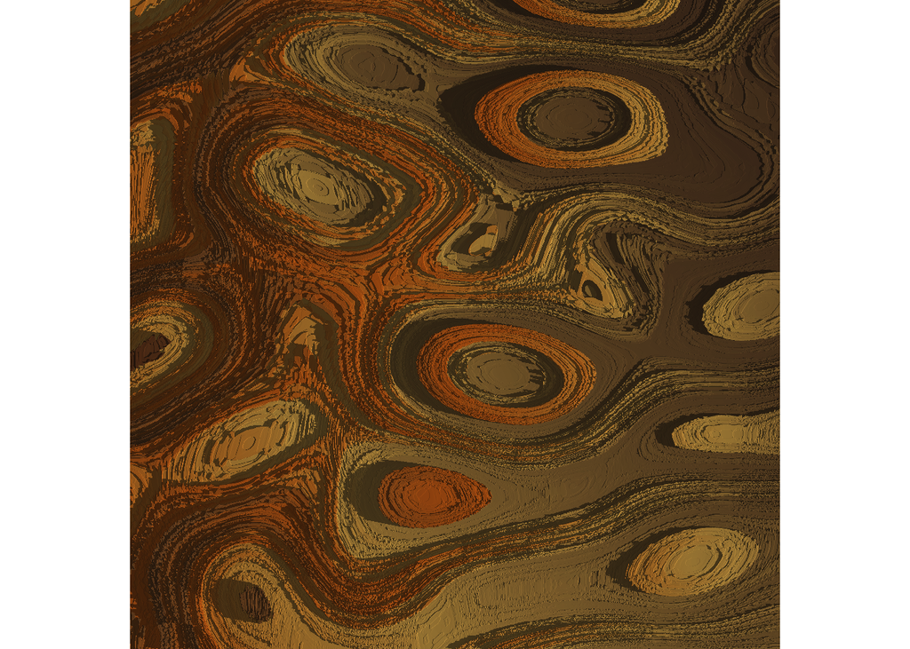

```r
shaded_ice_floe <- function(seed) {

  art <- ice_floe(seed) # create ice floe texture

  height_shade(
    heightmap = art, # heights created by ice floe
    texture = dune_pal_generator(seed, pal = dune_pal, n = 256) # use my dune pal
  ) |>
    # adding shadow using ice floe
    add_shadow(
      shadowmap = ray_shade(
        heightmap = art,
        sunaltitude = 20,
        sunangle = 100,
        multicore = TRUE,
        zscale = .01
      ),
      max_darken = .075
    ) |>
    plot_map()
}

shaded_ice_floe(892)
```

- 3D Ice Floe

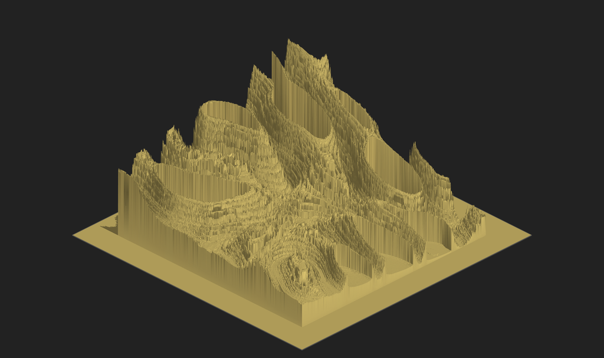

```r
dune_texture <- create_texture(
  lightcolor = "#e0c16c",
  shadowcolor = "#7d2a06",
  leftcolor = "#e6cf78",
  rightcolor = "#cc9129",
  centercolor = "#e0c872"
)


seed <- 13239587

ice_height <- matrix(0, 2500, 2500) # a matrix of elevations
ice_height[251:2250, 251:2250] <- ice_floe(seed)

ice_scape <- sphere_shade(
  heightmap = ice_height,
  texture = dune_texture # my custom color scale
) |>
  add_shadow(
    shadowmap = ray_shade(
      heightmap = ice_height,
      sunaltitude = 30,
      sunangle = 90,
      multicore = TRUE,
      zscale = .005
    ),
    max_darken = .15
  )
# create 3d version with ice_floe shading and elevation matrix
plot_3d(
  hillshade = ice_scape,
  heightmap = ice_height,
  theta = 45,
  phi = 30,
  zoom = .75,
  zscale = .001,
  background = "#222222",
  shadow = FALSE,
  soliddepth = .5,
  solidcolor = "#222222",
  windowsize = c(2500, 1500)
)

# create png of 3D image
render_snapshot(
  filename = here::here("images","exhibit2.png"),
  clear = TRUE
)

# display png
knitr::include_graphics(here::here("images","exhibit2.png"))
```

**Exhibit: **“City of Sand-Scrapers”**

- Initially inspired by the colors of Arrakis in the Dune movie, Reminiscent of sand’s interactions with magnets, this piece appears to appear as a large city with sand-scrapers (sky-scrapers made of sand), in a 3D format.
  - The image was created using the `rayshader` package and the `ice_floe` function we defined earlier. This 3D portrait was able to become 3D by the use of the `sphere_shade` function which creates a color map for the image, the `add_shadow` function which adds shadows to the image given the sun angles, and the `plot_3d` function which plots the 3D image. The use of a custom color palette created from the colors of the Dune movie poster gives this piece a unique flair. The heights of the sand skyscrapers were created by initializing a matrix of elevations, and generating a random “ice floe” using the `ice_floe` system (jagged, geometric-styled plots).